# merged_all_weeks

## Draw a sine curve

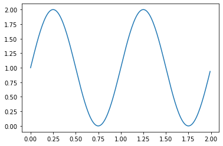

```python
import matplotlib.pyplot as plt
import numpy as np

# Data for plotting
t = np.arange(0.0, 2.0, 0.01)
s = 1 + np.sin(2 * np.pi * t)

fig, ax = plt.subplots()
ax.plot(t, s)

plt.show()
```

## Compute GCD of two numbers

```python
def gcd(m, n):
  common_factors = []

  for i in range(1, min(m, n) + 1):
    if m % i == 0 and n % i == 0:
      common_factors.append(i)

  return common_factors[-1]
```

```python
def gcd(m, n):
  for i in range(1, min(m, n) + 1):
    if m % i == 0 and n % i == 0:
      largest_common_factor = i

  return largest_common_factor
```

```python
print(f'GCD: {gcd(40, 60)}')
```

```
GCD: 20
```

# Check primality

### A prime number 'n' has only 2 factors i.e. 1 and n

> The number 1 is NOT a prime number

```python
def factors(n):
  factors = []

  for i in range(1, n + 1):
    if n % i == 0:
      factors.append(i)

  return factors
```

```python
def prime(n):
  return factors(n) == [1, n]
```

```python
def primes_upto(m):
  primes = []

  for i in range(1, m + 1):
    if prime(i):
      primes.append(i)

  return primes
```

```python
def first_primes(m):
  count = 0
  i = 0
  primes = []

  while count < m:
    if prime(i):
      primes.append(i)
      count += 1
    i += 1

  return primes
```

```python
def prime(n):
  flag = True

  for i in range(2, n):
    if n % i == 0:
      flag = False
      break

  return flag
# Better implementation below this code block
```

```python
# A better implementation for the above code
def prime(n):
  flag = True
  i = 2

  while flag and i < n:
    if n % i == 0:
      flag = False
    i += 1

  return flag
```

```python
# An optimized implementation
import math

def prime(n):
  flag = True
  i = 2

  while flag and i < math.sqrt(n):
    if n % i == 0:
      flag = False
    i += 1

  return flag
```

```python
# Difference between two primes
def prime_diffs(n):
  previous = 2
  dict = {}

  for i in range(3, n + 1):
    if prime(i):
      diff = i - previous
      previous = i

      if diff in dict.keys():
        dict[diff] += 1
      else:
        dict[diff] = 1

  return dict
```

## GCD

```python
def gcd(m, n):
  a = max(m, n)
  b = min(m, n)

  if a % b == 0:
    return b

  return gcd(b, a - b)
```

### Euclid's algorithm

```python
def gcd(m, n):
  a = max(m, n)
  b = min(m, n)

  if a % b == 0:
    return b

  return gcd(b, a % b)
```

## Handling Exceptions

```python
try:
  ...
  ...
except IndexError:
  ...
except (NameError, KeyError):
  ...
except:
  ...
else:
  ...
```

[output not shown]

## Using Exceptions 'positively'

### Traditional approach

```python
if b in scores.keys():
  scores[b].append(s)
else:
  scores[b] = [s]
```

### Using exceptions

```python
try:
  scores[b].append(s)
except KeyError:
  scores[b] = [s]
```

## Classes and Objects

#### Example: 2D Points

```python
class Point:
  def __init__(self, a = 0, b = 0):
    self.x = a
    self.y = b

  def translate(self, delta_x, delta_y):
    self.x += delta_x
    self.y += delta_y

  def origin_distance(self):
    import math
    return math.sqrt(self.x ** 2 + self.y ** 2)
```

#### Polar Coordinates

- Uses `(r, theta)` instead of `(x, y)`

```python
import math

class Point:
  def __init__(self, a = 0, b = 0):
    self.r = math.sqrt(a * a + b * b)

    if a == 0:
      self.theta = math.pi / 2
    else:
      self.theta = math.atan(b / a)

  def origin_distance(self):
    return self.r

  def translate(self, delta_x, delta_y):
    x = self.r * math.cos(self.theta)
    y = self.r * math.sin(self.theta)

    x += delta_x
    y += delta_y
    self.r = math.sqrt(x * x + y * y)

    if x == 0:
      self.theta = math.pi / 2
    else:
      self.theta = math.atan(y / x)
```

## Special functions

- `__init__()` is a constructor
- `__str__()` converts an object to a string
- `str(o) == o.__str__()`
- Implicitly invoked by a `print()`

```
class Point:
   ...
   def __str__(self):
     return '(' + str(self.x) + ',' + str(self.y) + ')'
```

- `__add__()`
- Implicitly invoked by `+`

```
def __add__(self, p):
  return Point(self.x + p.x, self.y + p.y)
```

## Classes and Objects, part 2

```python
class Point:
  def __init__(self, a = 0, b = 0):
    self.x = a
    self.y = b

  def translate(self, delta_x, delta_y):
    self.x += delta_x
    self.y += delta_y

  def origin_distance(self):
    import math
    return math.sqrt(self.x ** 2 + self.y ** 2)
```

```python
p = Point(3, 4)
q = Point(7, 11)
```

```python
print(p)
```

[output not shown]

```python
print(p + q)
```

[output not shown]

```python
p.origin_distance(), q.origin_distance()
```

```
(5.0, 13.038404810405298)
```

```python
p.r, p.theta
```

[output not shown]

```python
class Point:
  def __init__(self, a = 0, b = 0):
    import math
    self.r = math.sqrt(a * a + b * b)

    if a == 0:
      self.theta = 0
    else:
      self.theta = math.atan(b / a)

  def origin_distance(self):
    return self.r

  def translate(self, delta_x, delta_y):
    import math

    x = self.r * cos(self.theta)
    y = self.r * sin(self.theta)

    x += delta_x
    y += delta_y
    self.r = math.sqrt(x * x + y * y)

    if x == 0:
      self.theta = 0
    else:
      self.theta = math.atan(y / x)
```

```python
class Point:
  def __init__(self, a = 0, b = 0):
    self.x = a
    self.y = b

  def translate(self, delta_x, delta_y):
    self.x += delta_x
    self.y += delta_y

  def origin_distance(self):
    import math
    return math.sqrt(self.x ** 2 + self.y ** 2)

  def __str__(self):
    return '(' + str(self.x) + ',' + str(self.y) + ')'

  def __add__(self, p):
    return Point(self.x + p.x, self.y + p.y)
```

## Timing our code

#### How long does it take for our code to execute?

- Depends on the language

#### Python has a library `time` with various useful functions

#### `perf_time()` is a performance counter

- Absolute value of `perf_time()` is not meaningful
- Compare 2 consecutive readings to get an interval
- Default unit is seconds
- Python usually executes 10^7 operations per second

```python
import time

start = time.perf_counter()
...
# Execute some code
...
end = time.perf_counter()

elapsed = end - start
```

### A Timer object

```python
import time

class Timer:
  def __init__(self):
    self._start = 0
    self._elapsed = 0

  def start(self):
    self._start = time.perf_counter()

  def stop(self):
    self._elapsed = time.perf_counter() - self._start

  def elapsed(self):
    return self._elapsed
```

## Timer class (An elaborate version of the previous code)

```python
import time

class TimeError(Exception):
  """A custom exception used to report error in the use of Timer class"""

class Timer:
  def __init__(self):
    self._start = 0
    self._elapsed = 0

  def start(self):
    if self._start is not None:
      raise TimeError('Timer is running. Use .stop()')

    self._start = time.perf_counter()

  def stop(self):
    if self._start is None:
      raise TimeError('Timer is not running. Use .start()')

    self._elapsed = time.perf_counter() - self._start
    self._start = None

  def elapsed(self):
    if self._elapsed is None:
      raise TimeError('Timer has not been run yet. Use .start()')

    return self._elapsed

  def __str__(self):
    return str(self._elapsed)
```

```python
t = Timer()
t.stop()

for j in range(4, 9):
  t.start()
  n = 0

  for i in range(10 ** j):
    n += i

  t.stop()
  print(j, t)
```

```
4 0.0013261670000019876
5 0.015540165000004436
6 0.14855284700001903
7 1.392939014999996
8 13.564524590000019
```

### GCD using naive algorithm

```python
def gcd(m, n):
  common_factors = []

  for i in range(1, min(m, n) + 1):
    if m % i == 0 and n % i == 0:
      common_factors.append(i)

  return common_factors[-1]
```

```python
gcd(567812346, 876543217)
```

```
1
```

### Recursive GCD using m - n

```python
def gcd(m, n):
  a, b = max(m, n), min(m, n)

  if a % b == 0:
    return b

  return gcd(b, a - b)
```

```python
gcd(2, 99999999)
```

```
1
```

### Euclid's algorithm

```python
def gcd(m, n):
  a, b = max(m, n), min(m, n)

  if a % b == 0:
    return b

  return gcd(b, a % b)
```

# Analysis of Algorithms

## Measuring performance

- Two main resources of interest
  - Running time: How long does the algorithm take?
  - Space: Memory Requirement
- Time depends on processing power
  - Impossible to change for a given hardware
  - Enhancing hardware has only a limited impact at a practical level
- Storage is limited by available memory
  - Easier to configure, augment
- Typically, we focus on time rather than space

## Input size

- Running time depends on input size
  - Larger array will take a longer time to sort
- Measure time efficiency as function of input size
  - Input size $n$
  - Running time $t(n)$
- Different inputs of size $n$ may take different amounts of time

#### Example 1

SIM cards vs Aadhaar cards

- $n = 10^9$ (almost) -- number of cards
- Naive algorithm: $t(n) = n^2$
- Clever algorithm: $t(n) = n \ log \ n$
  - $log \ n$ -- number of times you need to divide $n$ by 2 to reach 1
  - $log \ n = k \implies n = 2^k$

#### Example 2

Video game

- Several objects on screen
- Basic step: find closest pair of objects
- $n$ objects -- naive algorithm is $n^2$
  - For each pair of objects, compute their distance
  - Report minimum distance across all pairs
- There is a clever algorithm that takes $n \ log \ n$ time
- High resolution gaming consoles may have $4000 \times 2000$ pixels
  - $8 \times 10^6$ points = 8 million points
- Suppose we have $100,000 = 10^5$ objects
- Naive algorithm takes $10^{10}$ steps
  - $1000$ seconds or $16.7$ minutes in Python
  - Its an unacceptable response time
- $log \ 100000$ is under $20$, so $n \ log \ n$ takes a fraction of a second

## Order of Magnitude

- When comparing $t(n)$, focus on the orders of magnitude
  - Ignore the constant factors
- $f(n) = n^3$ eventually grows faster than $g(n) = 5000n^2$
  - For small values of $n$, $f(n) < g(n)$
  - After $n = 5000$, $f(n)$ overtakes $g(n)$
- Asymptotic complexity
  - What happens in the limit, as $n$ becomes large
- Typical growth functions
  - Is $t(n)$ proportional to $log \ n,n, ..., n^2, n^3, ..., 2^n?$
  - Logarithmic, polynomial, exponential

[figure not shown]

## Measuring running time

- Analysis should be independent of the underlying hardware
  - Don't use actual time
  - Measure in terms of basic operations
- Typical basic operations
  - Compare two values
  - Assign a value to a variable

## What is the input size

- Typically a natural parameter
  - Size of a list/array that we want to search or sort
  - Number of objects we want to rearrange
  - Number of vertices and number of edges in a graph
    - We shall see why these are separate parameters
- What about numeric problems? Is $n$ a prime?
  - Magnitude of $n$ is not the correct measure
  - Arithmetic operations are performed digit by digit
    - Addition with carry, subtraction with borrow, multiplication, long division ...
  - Number of digits is a natural measure of input size

## Which inputs should we consider?

- Performance varies across input instances
- Ideally, we want the "average" behaviour
  - But it is difficult to compute
  - Average over what? Are all inputs equally likely?
  - Need a probability distribution over inputs
- Instead, we use the worst case input
  - Input that forces algorithm to take the longest possible time
    - Search for a value which is not present in an unsorted list
    - Must scan all the elements
  - Pessimistic - worst case may be rare
  - Upper bound for worst case guarantees good performance

# Comparing orders of Magnitude

## Upper bounds

- $f(x)$ is said to be $O(g(x))$ if we can find constants $c$ and $x_0$ such that $c.g(x)$ is an upper bound for $f(x)$ for $x$ beyond $x_0$
  - The $O$ is called the Big-O Notation
- $f(x) \leq cg(x)$ for every $x \geq x_0$

## Example

- $100n + 5$ is $O(n^2)$
  - $100n + 5 \leq 100n + n = 101n$ for $n \geq 5$
  - $101n \leq 101n^2$
  - Choose $n_0 = 5, c = 101$
- Alternatively
  - $100n + 5 \leq 100n + 5n = 105n$ for $n \geq 1$
  - $105n \leq 105n^2$
  - Choose $n_0 = 1, c = 105$
- Choice of $n_0, c$ is not unique

## Example

- $100n^2 + 20n + 5$ is $O(n^2)$
  - $100n^2 + 20n + 5 \leq 100n^2 + 20n^2 + 5n^2$ for $n \geq 1$
  - $100n^2 + 20n + 5 \leq 125n^2$ for $n \geq 1$
  - Choose $n_0 = 1, c = 125$
- What really matters is the highest term
  - $20n + 5$ is dominated by $100n^2$
- Similarly, $n^3$ is not $O(n^2)$
  - No matter what $c$ we choose, $cn^2$ will be dominated by $n^3$ for $n \geq c$

## Useful properties

- If $f_1(n)$ is $O(g_1(n))$ and $f_2(n)$ is $O(g_2(n))$, then $...$
  - $f_1(n) + f_2(n)$ is $O(max(g_1(n), g_2(n)))$
  - **The least efficient phase is the upper bound for the whole algorithm**

## Lower bounds

- $f(x)$ is said to be $\Omega(g(x))$ if we can find constants $c$ and $x_0$ such that $cg(x)$ is a lower bound for $f(x)$ for $x$ beyond $x_0$
  - $f(x) \geq cg(x)$ for every $x \geq x_0$
- $n^3$ is $\Omega(n^2)$
  - $n^3 \gt n^2$ for all $n$, so $n_0 = 1, c = 1$
- Typically, we establish lower bounds for a problem rather than an individual algorithm
  - If we sort a list by comparing elements and swapping them, we require $\Omega(n \ log \ n)$ comparisons
  - This is independent of the algorithm we use for sorting

## Tight bounds

- $f(x)$ is said to be $\Theta(g(x))$, if it is both $O(g(x))$ and $\Omega(g(x))$
  - Find constants $c_1, c_2, x_0$ such that $c_1.g(x) \leq f(x) \leq c_2.g(x)$ for every $x \geq x_0$
- $n(n - 1)/2$ is $\Theta(n^2)$
  - Upper bound
    - $n(n - 1)/2 = n^2/2 - n/2 \leq n^2/2$ for all $n \geq 0$
  - Lower bound
    - $n(n - 1)/2 = n^2/2 - n/2 \geq n^2/2 - (n/2 \times n/2) \geq n^2/4$ for $n \geq 2$
  - Choose $n_0 = 2, c_1 = 1/4, c_2 = 1/2$

## Summary

- $f(n)$ is $O(g(n))$ means $g(n)$ is an upper bound for $f(n)$
  - Useful to describe asymptotic worst case running time
- $f(n)$ is $\Omega(g(n))$ means $g(n)$ is a lower bound for $f(n)$
  - Typically used for a problem as a whole, rather than an individual algorithm
- $f(n)$ is $\Theta(g(n))$: matching upper and lower bounds
  - We have found an optimal algorithm for a problem

# Calculating Complexity -- Examples

## 2 types of programs

- Iterative programs
- Recursive programs

### Example #1

Find the maximum element in a list

- Input size is the length of the list
- Single loop scans all the elements
- Always takes $n$ steps
- Overall time is $O(n)$

```python
def maxElement(L):
  max = L[0]
  for i in range(len(L)):
    if L[i] > max:
      max = L[i]
  return max
```

### Example #2

Check whether a list contains duplicates

- Input size is length of the list
- Nested loop scans all pairs of elements
- A duplicate may be found in the very first iteration
- Worst Case: no duplicates, both loops run fully
- Time is $(n - 1) + (n - 2) + ... + 1 = n(n - 1)/2$
- Overall time is $O(n^{2})$

```python
def noDuplicates(L):
  for i in range(len(L)):
    for j in range(i, len(L)):
      if L[i] == L[j]:
        return False
  return True
```

### Example 3

Matrix Multiplication

- Matrix is represented as a list of lists
  - [[1, 2, 3], [4, 5, 6]]
- Input matrices have size $m \times m, n \times p$
- Output matrix is $m \times p$
- Three nested loops
- Overall time is $O(m.n.p) - O(n^{3})$ if both are $n \times n$

```python
def matrixMultiply(A, B):
  (m, n, p) = (len(A), len(B), len(B[0]))
  C = [[0 for i in range(p)]
        [for j in range(n)]]

  for i in range(m):
    for j in range(p):
      for k in range(n):
        C[i][j] = C[i][j] + A[i][k] * B[k][j]

  return C
```

### Example 4

Number of bits in binary representation of $n$

- $log \ n$ steps for $n$ to reach $1$
- For number theoretic problems, input size is number of digits
- The algorithm is linear in input size

```python
def numberOfBits(n):
  count = 1
  while n > 1:
    count += 1
    n = n // 2
  return count
```

### Example 5

Towers of Hanoi

- Three pegs A, B, C
- Move $n$ disks from A to B, use C as transit peg
- Never put a larger disk on a smaller one

Recursive solution

- Move $n - 1$ disks from A to C, use B as a transit peg
- Move largest disk from A to B
- Move $n - 1$ disks from C to B, use A as a transit peg

Recurrence

- $M(n)$ be the number of moves to transfer $n$ disks
- $M(1) = 1$
- $M(n) = M(n - 1) + 1 + M(n - 1) = 2M(n - 1) + 1$

Unwind and solve  
$M(n) = 2M(n - 1) + 1$  
$= 2(2M(n - 2) + 1) + 1 = 2^{2}M(n - 2) + (2 + 1)$  
$= 2^{2}(2M(n - 3) + 1) + (2 + 1) = 2^{3}M(n - 3) + (4 + 2 + 1)$  
...  
$= 2^{k}M(n - k) + (2^{k} - 1)$  
...  
$= 2^{n-1}M(1) + (2^{n-1} - 1)$ $= 2^{n-1} + 2^{n-1} - 1 = 2^{n} - 1$

## Summary

- Iterative programs
  - Focus on hoops
- Recursive programs
  - Write and solve a recurrence
- Need to be clear about accounting for "basic" operations

# Searching in a List

## Naive search (Linear search)

- Is the value $v$ present in list $l$?
- Naive solution scans the list
- Input size $n$, the length of the list
- Worst case is when $v$ is not present in the list $l$
- Worst case complexity is $O(n)$

```python
def naive_search(v, l):
  for x in l:
    if v == x:
      return True
  return False
```

## Searching a sorted list (Binary search)

- What if $l$ is sorted in ascending order?
- Compare $v$ with the midpoint of $l$
  - If midpoint is $v$, the value is found
  - If $v$ is less than midpoint, search the first (left) half
  - If $v$ is greater than midpoint, search the second (right) half
  - Stop, when the interval to search becomes empty
- How long does this take?
  - Each call halves the interval to search
  - Stop when the interval becomes empty
- $log \ n$ - number of times to divide $n$ by $2$ to reach $1$
  - $1 // 2 = 0$ so next call reaches empty interval
- $O(log \ n)$ steps

```python
def binary_search(v, l):
  if l == []:
    return False

  n = len(l) // 2
  if v == l[n]:
    return True
  if v < l[n]:
    return binary_search(v, l[:n])
  else:
    return binary_search(v, l[n + 1:])
```

## Summary

- Search in an unsorted list takes $O(n)$ time
  - We need to scan the entire list
  - Worst case is when the value is not present in the list
- For a sorted list, binary search takes time $O(log \ n)$
  - Half the interval to search each time
- In a sorted list, we can determine that $v$ is absent by examining just $log \ n$ values.

# Sorting Algorithms

## Sorting a List

- Sorting a list makes many other computations easier
  - Binary search
  - Finding the median
  - Check for duplicates
  - Building a frequency table of views
- How do we sort a list?
- **Eg:** You are the TA for a course
  - Instructor has a pile of evaluated exam papers
  - Papers in random order of marks
  - Your task is to arrange the papers in descending order of marks
  - Strategy 1
    - Scan the entire pile and find the paper with minimum marks
    - Move this paper to a new pile
    - Repeat with the remaining papers
      - Add the paper with the next minimum marks to the second pile each time
    - Eventually, the new pile is sorted in descending order

### Selection Sort

- Select the next element in the sorted order
- Append it to the final sorted list
- Avoid using a second list
  - Swap the minimum element into the first position
  - Swap the second minimum element into the second position
  - ...
- Eventually the list will be sorted in ascending order **(in-place)**

### Analysis of selection sort

- Correctness follow from the invariant
- Efficiency
  - Outer loop: iterates $n$ times
  - Inner loop: $n - i$ steps to find minimum in $L[i:]$
  - $T(n) = n + (n - 1) + ... + 1$
  - $T(n) = n(n + 1)/2$
- $T(n)$ is $O(n^{2})$

```python
def selection_sort(L):
  n = len(L)
  if n <= 1:
    return L

  for i in range(n):
    min_index = i

    for j in range(i + 1, n):
      if L[j] < L[min_index]:
        min_index = j

    L[i], L[min_index] = L[min_index], L[i]

  return L
```

## Summary

- Selection sort is an intuitive algorithm to sort a list
- Repeatedly find the min (or max) and append to the sorted list
- Worst case complexity is $O(n^{2})$
  - Every input takes this much time
  - No advantage even if the list is arranged carefully before sorting

## Sorting Algorithms (part 2)

#### Sorting a list

- You are the TA for a course
  - Instructor has a pile of evaluated exam papers
  - Papers are in random order of marks
  - Your task is to arrange the papers in descending order of marks
  - Strategy 2
    - Move the first paper to a new pile
    - Second paper
      - Lower marks than the first? Place below the first paper in the new pile
      - Higher marks than the first? Place above the first paper in the new pile
    - Third paper
      - Insert into the correct position with respect to the first two
    - Do this for the remaining papers
      - Insert each one into the correct position in the second pile

### Insertion sort

- Start building a new sorted list
- Pick next element and insert it into the sorted list
- An iterative formulation
  - Assume $L[:i]$ is sorted
  - Insert $L[i]$ in $L[:i]$
- Analysis of iterative insertion sort
  - Correctness follows from the invariant
  - Efficiency
    - Outer loop interates $n$ times
    - Innser loop: $i$ steps to insert $L[i]$ in $L[:i]$
    - $T(n) = 0 + 1 + ... + (n - 1)$
    - $T(n) = n(n - 1)/2$
  - $T(n)$ is $O(n^{2})$

```python
# An iterative solution
def insertion_sort(L):
  n = len(L)
  if n <= 1:
    return L

  for i in range(n):
    j = i

    while j > 0 and L[j] < L[j - 1]:
      L[j], L[j - 1] = L[j - 1], L[j]
      j = j - 1

  return L
```

- A recursive formulation
  - Inductively sort $L[:i]$
  - Insert $L[i]$ in $L[:i]$
- Analysis of recursive insertion sort
  - For the input size of $n$, let
    - $TI(n)$ be the time taken by `insert()`
    - $TS(n)$ be the time taken by `insertion_sort()`
  - First calculate $TI(n)$ for `insert()`
    - $TI(0) = 1$
    - $TI(n) = TI(n - 1) + 1$
    - Unwind to get $TI(n) = n$
  - Set up a recurrence for $TS(n)$
    - $TS(0) = 1$
    - $TS(n) = TS(n - 1) + TI(n - 1)$
  - Unwind to get $1 + 2 + ... + n - 1$

```python
# A recursive implementation
def insert(L, v):
  n = len(L)
  if n == 0:
    return [v]

  if v >= L[-1]:
    return L + [v]
  else:
    return insert(L[:-1], v) + L[-1:]

def insertion_sort(L):
  n = len(L)
  if n <= 1:
    return L

  L = insert(insertion_sort(L[:-1]), L[-1])
  return L
```

## Summary

- Insertion sort is another intuitive algorithm to sort a list
- Create a new sorted list
- Repeatedly insert elements into the sorted list
- Worst case complexity is $O(n^{2})$
  - Unlike selection sort, not all cases take time $n^{2}$
  - If list is already sorted `insert()` stops in 1 step
  - Overall time can be close to $O(n)$

# Sorting Algorithms (part 3)

## Beating the $O(n^{2})$ barrier

- Both selection sort and insertion sort take time $O(n^{2})$
- This is infeasible for $n > 10,000$
- How can we bring the complexity below $O(n^{2})$?

### Strategy 3

- Divide the list in two halves
- Separately sort the left and right half
- Combine the two sorted halves to get a fully sorted list

### Combining two sorted lists

- Combine two sorted lists **A** and **B** into a single sorted list **C**
  - Compare the first elements of both **A** and **B**
  - Move the smaller of the two to **C**
  - Repeat till you exhaust **A** and **B**
- Merging **A** and **B**

## Merge sort

- Let $n$ be the length of $L$
- Sort $A[:n // 2]$
- Sort $A[n // 2:]$
- Merge the sorted halves into **B**
- How do we sort $A[:n // 2]$ and $A[n // 2:]$?
  - Recursively, using the same strategy

## Divide and Conquer

- Break up the problem into disjoint parts
- Solve each part separately
- Combine the solutions efficiently

## Merging sorted lists

- Combining two sorted lists **A** and **B** into **C**
  - if **A** is empty, copy **B** into **C**
  - if **B** is empty, copy **A** into **C**
  - Otherwise, compare first elements of **A** and **B**
    - Move the smaller of the two to **C**
  - Repeat till all the elements of **A** and **B** have been moved

```python
def merge(A, B):
  m, n = len(A), len(B)
  C, i, j, k = [], 0, 0, 0

  while k < m + n:
    if i == m:
      C.extend(B[j:])
      k += (n - j)
    elif j == n:
      C.extend(A[i:])
      k += (n - i)
    elif A[i] < B[j]:
      C.append(A[i])
      i += 1
      k += 1
    else:
      C.append(B[j])
      j += 1
      k += 1

  return C
```

```python
# The above implementation is by Prof. Madhavan, which I find a bit too difficult for my ADHD brain
# So, here's my implementation of merge()

def merge(left, right):
    m = len(left)
    n = len(right)
    i = 0
    j = 0
    sorted = []

    while i < m and j < n:
        if left[i] < right[j]:
            sorted.append(left[i])
            i += 1
        else:
            sorted.append(right[j])
            j += 1

    sorted.extend(left[i:])
    sorted.extend(right[j:])
    return sorted
```

### Merge sort

- To sort **A** into **B**, both of length $n$
- If $n \leq 1$, nothing is to be done
- Otherwise
  - Sort $A[:n//2]$ into $L$
  - Sort $A[n//2:]$ into $R$
  - Merge $L$ and $R$ into **B**

```python
def merge_sort(A):
  n = len(A)
  if n <= 1:
    return A

  L = merge_sort(A[:n//2])
  R = merge_sort(A[n//2:])

  return merge(L, R)
```

## Summary

- Merge sort using divide and conquer to sort a list
- Divide the list into two halves
- Sort each half
- Merge the sorted halves
- Next, we have to check that the complexity is less than $O(n^{2})$

# Sorting Algorithms (part 4)

## Merge Sort

- To sort **A** into **B**, both of length $n$
- If $n \leq 1$, nothing is to be done
- Otherwise
  - Sort `A[:n//2]` into **L**
  - Sort `A[n//2:]` into **R**
  - Merge **L** and **R** into **B**

Merging two sorted lists **A** and **B** into **C**

- If **A** is empty, copy **B** into **C**
- If **B** is empty, copy **A** into **C**
- Otherwise, compare the first elements of **A** and **B**
  - Move the smaller of the two to **C**
- Repeat till all the elements of **A** and **B** have been moved

#### Analysing `merge()`

- Merge **A** of length `m`, **B** of length `n`
- Output list **C** has length $m + n$
- In each iteration, we add (at least) one element to **C**
- Hence, `merge()` takes time $O(m+n)$
- Recall that $m+n \leq 2(max(m, n))$
- If $m \approx n$, `merge()` takes time $O(n)$

#### Analysing `merge_sort()`

- Let $T(n)$ be the time taken for input of size $n$
  - For simplicity, assume $n = 2^{k}$ for some $k$
- Recurrence
  - $T(0) = T(1) = 1$
  - $T(n) = 2T(n/2) + n$
    - Solve two sub-problems of size $n/2$
    - Merge the solutions in time $n/2 + n/2 = n$
- Unwind the recurrence to solve

[figure not shown]

### Summary

- Merge sort takes time $O(nlogn)$ so can be effectively used on large inputs
- Variations on merge are possible
  - Union of two sorted lists - discard duplicates, if `A[i] == B[j]` move just one copt to **C** and increment both `i` and `j`
  - Intersection of two sorted lists - when `A[i] == B[j]`, move one copy to **C**, otherwise discrd the smaller of `A[i]`, `B[j]`
  - List difference - elements in **A** but not in **B**
- Merge needs to create a new list to hold the merged elements
  - No obvious way to effeciently merge two lists in place
  - Extra storage can be costly
- Inherently recursive
  - Recursive calls and returns are epensive

# Implementation of Searching & Sorting algorithms

## Setup

- Set up the `Timer` class to time execution

```python
import time

class TimerError(Exception):
  """A custom exception used to report errors in use of Timer class"""

class Timer:
  def __init__(self):
    self._start_time = None
    self._elapsed_time = None

  def start(self):
    """Start a new timer"""
    if self._start_time is not None:
      raise TimerError('Timer is running. Use .stop()')

    self._start_time = time.perf_counter()

  def stop(self):
    """Save the elapsed time and re-initialize the timer"""
    if self._start_time is None:
      raise TimerError('Timer is not running. Use .start()')

    self._elapsed_time = time.perf_counter() - self._start_time
    self._start_time = None

  def elapsed(self):
    """Report the elapsed time"""
    if self._elapsed_time is None:
      raise TimerError('Timer has not been run yet. Use .start()')

    return self._elapsed_time

  def __str__(self):
    """print() prints the elapsed"""
    return str(self._elapsed_time)
```

#### Naive search by scanning the list

```python
def naive_search(v, l):
  for x in l:
    if x == v:
      return True

  return False
```

#### Binary search

```python
def binary_search(v, l):
  if l == []:
    return False

  mid = len(l) // 2
  if v == l[mid]:
    return True

  if v < l[mid]:
    return binary_search(v, l[:mid])
  else:
    return binary_search(v, l[mid + 1:])
```

#### Checking correctness on input [0, 2, ..., 50]

```python
l = list(range(0, 51, 2))

for i in range(51):
  print(f'[{i}, {naive_search(i, l)}]', end=', ')
print()

for i in range(51):
  print(f'[{i}, {binary_search(i, l)}]', end=', ')
print()
```

```
[0, True], [1, False], [2, True], [3, False], [4, True], [5, False], [6, True], [7, False], [8, True], [9, False], [10, True], [11, False], [12, True], [13, False], [14, True], [15, False], [16, True], [17, False], [18, True], [19, False], [20, True], [21, False], [22, True], [23, False], [24, True]…
[0, True], [1, False], [2, True], [3, False], [4, True], [5, False], [6, True], [7, False], [8, True], [9, False], [10, True], [11, False], [12, True], [13, False], [14, True], [15, False], [16, True], [17, False], [18, True], [19, False], [20, True], [21, False], [22, True], [23, False], [24, True]…
```

- Looking for odd numbers in a list of even numbers

```python
l = list(range(0, 100000, 2))
t = Timer()

t.start()
for i in range(3001, 13000, 2):
  v = naive_search(i, l)
t.stop()

print()
print('Naive Search', t)

t.start()
for i in range(3001, 13000, 2):
  v = binary_search(i, l)
t.stop()

print()
print('Binary search', t)
```

```
Naive Search 10.719358297000042

Binary search 0.8333934999999997
```

### Selection sort

```python
def selection_sort(L):
  n = len(L)
  if n < 1:
    return L

  for i in range(n):
    min_index = i

    for j in range(i + 1, n):
      if L[j] < L[min_index]:
        min_index = j

    L[i], L[min_index] = L[min_index], L[i]

  return L
```

#### Selection sort performance is more or less the same for all inputs

```python
import random
random.seed(2021)

input_lists = {}
input_lists['random'] = [random.randrange(100000) for i in range(5000)]
input_lists['ascending'] = [i for i in range(5000)]
input_lists['descending'] = [i for i in range(4999, -1, -1)]

t = Timer()
for k in input_lists.keys():
  temp_list = input_lists[k][:]
  t.start()
  selection_sort(temp_list)
  t.stop()
  print(k, t)
```

```
random 1.250216086000023
ascending 1.2441596080000181
descending 1.320314938000024
```

#### Insertion sort, iterative

```python
def insertion_sort(L):
  n = len(L)
  if n < 1:
    return L

  for i in range(n):
    j = i
    while j > 0 and L[j] < L[j - 1]:
      L[j], L[j - 1] = L[j - 1], L[j]
      j = j - 1

  return L
```

#### Insertion sort performance

- On already sorted input, performance is very good
- On reverse sorted input, performance is worse than selection sort

```python
import random
random.seed(2021)

input_lists = {}
input_lists['random'] = [random.randrange(100000) for i in range(5000)]
input_lists['ascending'] = [i for i in range(5000)]
input_lists['descending'] = [i for i in range(4999, -1, -1)]

t = Timer()
for k in input_lists.keys():
  temp_list = input_lists[k][:]
  t.start()
  insertion_sort(temp_list)
  t.stop()
  print(k, t)
```

```
random 2.379664321000064
ascending 0.0008934370000588387
descending 4.673232396000003
```

### Insertion sort, recursive

```python
def insert(L, v):
  n = len(L)
  if n == 0:
    return [v]

  if v >= L[-1]:
    return L + [v]
  else:
    return insert(L[:-1], v) + L[-1:]


def ins_sort(L):
  n = len(L)
  if n < 1:
    return L

  return insert(ins_sort(L[:-1]), L[-1])
```

```python
import random
random.seed(2021)

input_lists = {}
input_lists['random'] = [random.randrange(100000) for i in range(5000)]
input_lists['ascending'] = [i for i in range(5000)]
input_lists['descending'] = [i for i in range(4999, -1, -1)]

t = Timer()
for k in input_lists.keys():
  temp_list = input_lists[k][:]
  t.start()
  ins_sort(temp_list)
  t.stop()
  print(k, t)
```

```
---------------------------------------------------------------------------
RecursionError                            Traceback (most recent call last)
<ipython-input-15-263247dace6c> in <module>()
     11   temp_list = input_lists[k][:]
     12   t.start()
---> 13   ins_sort(temp_list)
     14   t.stop()
     15   print(k, t)

<ipython-input-14-aacadf208ca6> in ins_sort(L)
     15     return L
     16
---> 17   return insert(ins_sort(L[:-1]), L[-1])

... last 1 frames repeated, from the frame below ...

<ipython-input-14-aacadf208ca6> in ins_sort(L)
     15     return L
     16
---> 17   return insert(ins_sort(L[:-1]), L[-1])

RecursionError: maximum recursion depth exceeded while calling a Python object
```

### Setup

> To overcome the default maximum recursion depth of Python (which is usually set to 1000)
- Set the recursion limit to maxint, i.e. $2^{31} - 1$
  - The highest value that Python allows

```python
import sys
sys.setrecursionlimit(2 ** 31 - 1)
```

#### Recursive insertion sort is slower than the iterative version

- Input of 2000 (40%) takes more time than 5000 for iterative
  - Overhead of recursive calls
- Performance pattern between unsorted, sorted and random is similar

```python
import random
random.seed(2021)

input_lists = {}
input_lists['random'] = [random.randrange(100000) for i in range(2000)]
input_lists['ascending'] = [i for i in range(2000)]
input_lists['descending'] = [i for i in range(1999, -1, -1)]

t = Timer()
for k in input_lists.keys():
  temp_list = input_lists[k][:]
  t.start()
  ins_sort(temp_list)
  t.stop()
  print(k, t)
```

```
random 12.180662461999873
ascending 0.029959382000015466
descending 21.513495066999894
```

### Merge sort

```python
def merge(A, B):
  m, n = len(A), len(B)
  C, i, j, k = [], 0, 0, 0

  while k < m + n:
    if i == m:
      C.extend(B[j:])
      k = k + (n - j)
    elif j == n:
      C.extend(A[i:])
      k = k + (n - i)
    elif A[i] < B[j]:
      C.append(A[i])
      i, k = i + 1, k + 1
    else:
      C.append(B[j])
      j, k = j + 1, k + 1

  return C
```

```python
def merge_sort(A):
  n = len(A)
  if n <= 1:
    return A

  L = merge_sort(A[:n // 2])
  R = merge_sort(A[n // 2:])

  return merge(L, R)
```

#### A simple input to check correctness

```python
merge_sort([i for i in range(0, 1000, 2)] + [j for j in range(1, 1000, 2)])
```

[output not shown]

[output cut: 945 more lines]

```
 985,
 986,
 987,
 988,
 989,
 990,
 991,
 992,
 993,
 994,
 995,
 996,
 997,
 998,
 999]
```

#### Performance on large inputs, $10^{6}$, random and sorted

```python
import random
random.seed(2021)

input_lists = {}
input_lists['random'] = [random.randrange(100000000) for i in range(1000000)]
input_lists['ascending'] = [i for i in range(1000000)]
input_lists['descending'] = [i for i in range(999999, -1, -1)]

t = Timer()
for k in input_lists.keys():
  temp_list = input_lists[k][:]
  t.start()
  merge_sort(temp_list)
  t.stop()
  print(k, t)
```

```
random 9.493494636999912
ascending 5.07402918899993
descending 5.157073330000003
```

## Quicksort

### Shortcomings of Merge Sort

- Merge needs to create a new list to hold the merged elements
  - No obvious way to efficiently merge two lists in place
  - Extra storage can be costly
- Inherently recursive
  - Recursive calls and returns are expensive
- Merging happens because elements in the left half need to move to the right half and vice-versa
  - Consider an input of the form `[0, 2, 4, 6, 1, 3, 5, 9]`
- So, can we divide the list so that everything on the left is smaller than everything on the right?
  - No need to merge

### Divide and Conquer without Merging

- Suppose the median value of $L$ is $m$
- Move all the values $\leq m$ to the left half of $L$
  - Right half has values $\gt m$
- Recursively, sort the left and the right halves
  - $L$ is now sorted, no merge needed
- Recurrence: $T(n) = 2T(n/2) + n$
  - Rearrange in a single pass, time $O(n)$
- So $T(n)$ is $O(n \ log \ n)$
- So, how do we find the median?
  - Sort and pick up the median
  - But wait a minute (ちょっと待って), our aim is to sort the list!
- Instead, pick some element in $L$ -- call it a `pivot`
  - Split $L$ with respect to the pivot element

### Quicksort - [[C.A.R. Hoare]](https://en.wikipedia.org/wiki/Tony_Hoare)

- Choose a pivot element
  - Typically the first element in the array
- Partition $L$ into lower and upper parts with respect to the pivot
- Move the pivot between the lower and upper partition
- Recursively sort the two partitions

**High level view of Quicksort**

- Input list `[43, 32, 22, 78, 63, 57, 91, 13]`
  - Identify pivot
  - Mark the lower elements and upper elements
- Re-arrange the elements as lower-pivot-upper
  - `[32, 22, 13, 43, 48, 63, 57, 91]`
- Recursively sort the lowert and upper partitions

### Partitioning

- Scan the list from left to right
- Four segments: Pivot, Lower, Upper, Unclassified
- Examine the first unclassified element
  - If it is larger than the pivot, extend Upper to include this element
  - If it is less than or equal to the pivot, exchange it with the first element in the Upper. This extends Lower and shift Upper by one position
- Pivot is always the first element
- Maintain the two indices (as pointers/markers) to mark the end of the Lower and Upper segments
- After partitioning, exchange the pivot with the last element of the Lower segment

```python
def quick_sort(L, l, r):  # Sort L[l:r]
  if r - l <= 1:
    return L

  pivot = L[l]
  lower = l + 1
  upper = l + 1

  for i in range(l + 1, r):
    if L[i] > pivot:  # Extend the upper segment, if the unclassified element is bigger then the pivot
      upper += 1
    else:             # Exchange the L[i] with start of the upper segment, this extends the lower segment without shifting every single element of the upper segment
      L[i], L[lower] = L[lower], L[i]
      # Now, shift both the segments
      lower += 1
      upper += 1

  # Move the pivot between lower and upper
  L[l], L[lower - 1] = L[lower - 1], L[l]
  lower -= 1

  # Recursive calls
  quick_sort(L, l, lower)
  quick_sort(L, lower + 1, upper)
  return L
```

### Summary

- Quicksort uses divide and conquer, like merge sort
- By partitioning the list carefully, we avoid a merge step
  - This allows us to sort in-place
- We can also provide an iterative implementation to avoid the cost of recursive calls
- The partitioning strategy we described is not the only one used in the literature
  - We can build the lower and upper segments from opposite ends and meet in the middle
- We need to analyse the complexity of Quick sort

## Quicksort

- Choose a pivot element
- Partition $L$ into lower and upper segments with respect to the pivot
- Move the pivot between the lower and upper segments
- Recursively sort the two partitions

### Analysis

- Partitioning with respect to the pivot takes time $O(n)$
- If the pivot is the median
  - $T(n) = 2T(n/2) + n$
  - $T(n)$ is $O(nlogn)$
- Worst case? Pivot is maximum or minimum
  - Partitions are of size $0, n - 1$
  - $T(n) = T(n - 1) + n$
  - $T(n) = n + (n - 1) + ... + 1$
  - $T(n)$ is $O(n^2)$
- Another worst case is when the array is already sorted!
- However, the average case is $O(nlogn)$
- Sorting is a rare sitatuation where we can compute this
  - Values do not matter, only relative positioning (order) is important
  - Analyze behaviour over permutations of ${1, 2, ..., n}$
  - Each input permutation is equally likely
- Expected running time is $O(nlogn)$

### Randomization

- Any fixed choice of pivot allows us to construct worst case input
- Instead, choose pivot position randomly at each step
- Expected running time is again $O(nlogn)$

### Iterative Quick sort

- Recursive calls work on disjoint segments
  - No re-combination of results is required
- Can explicitly keep track of left and right endpoints of each segment to be sorted

### Quicksort in practice

- In practice, quicksort is very fast
- Very often, it is the default algorithm used for in-built sort functions
  - Sorting a columnn in a spreadsheet
  - Library sort function in a programming language

### Summary

- The worst case compelexity of quick sort is $O(n^2)$
- However, the average case is $O(nlogn)$
- Randomly choosing the pivot is a good strategy to beat the worst case inputs
- Quicksort works in-place and can be implemented iteratively
- Very fast in practice, and is often used for built-in sorting functions
  - Good example of a situation when the worst case upper bound is pessimistic

## Quicksort implementation

```python
import time

class TimeError(Exception):
  """A custom exception used to report error in the use of Timer class"""

class Timer:
  def __init__(self):
    self._start = 0
    self._elapsed = 0

  def start(self):
    if self._start is not None:
      raise TimeError('Timer is running. Use .stop()')

    self._start = time.perf_counter()

  def stop(self):
    if self._start is None:
      raise TimeError('Timer is not running. Use .start()')

    self._elapsed = time.perf_counter() - self._start
    self._start = None

  def elapsed(self):
    if self._elapsed is None:
      raise TimeError('Timer has not been run yet. Use .start()')

    return self._elapsed

  def __str__(self):
    return str(self._elapsed)
```

```python
import sys
sys.setrecursionlimit(2 ** 31 - 1)
```

```python
def quick_sort(L, l, r):
  if r - l <= 1:
    return L

  pivot, lower, upper = L[l], l + 1, l + 1

  for i in range(l + 1, r):
    if L[i] > pivot:
      upper += 1
    else:
      L[i], L[lower] = L[lower], L[i]
      lower, upper = lower + 1, upper + 1

  L[l], L[lower - 1] = L[lower - 1], L[l]
  lower -= 1

  quick_sort(L, l, lower)
  quick_sort(L, lower + 1, upper)

  return L
```

```python
qlist = [1, 3, 5, 0, 2, 4, 17, 2, -5, 6, 4, 3]
qnew = quick_sort(qlist, 0, 12)

print(qnew, qlist)
```

```
[-5, 0, 1, 2, 2, 3, 3, 4, 4, 5, 6, 17] [-5, 0, 1, 2, 2, 3, 3, 4, 4, 5, 6, 17]
```

```python
import random
random.seed(2021)
input_lists = {}

input_lists['random'] = [random.randrange(100000000) for i in range(1000000)]
input_lists['ascending'] = [i for i in range(10000)]
input_lists['descending'] = [i for i in range(9999, -1, -1)]

t = Timer()
t.stop()
for k in input_lists.keys():
  temp_list = input_lists[k][:]
  t.start()
  quick_sort(temp_list, 0, len(temp_list))
  t.stop()
  print(k, t)
```

```
random 5.297362751000037
ascending 5.691851239000016
descending 8.883204298999999
```

```python
def merge(A, B):
  m, n = len(A), len(B)
  C, i, j, k = [], 0, 0, 0

  while k < m + n:
    if i == m:
      C.extend(B[j:])
      k += n - j
    elif j == n:
      C.extend(A[i:])
      k += n - i
    elif A[i] < B[j]:
      C.append(A[i])
      i, k = i + 1, k + 1
    else:
      C.append(B[j])
      j, k = j + 1, k + 1

  return C
```

```python
def merge_sort(A):
  n = len(A)
  if n <= 1:
    return A

  L = merge_sort(A[: n // 2])
  R = merge_sort(A[n // 2:])

  return merge(L, R)
```

```python
import random
random.seed(2021)
input_lists = {}

input_lists['random'] = [random.randrange(100000000) for i in range(1000000)]
input_lists['ascending'] = [i for i in range(1000000)]
input_lists['descending'] = [i for i in range(999999, -1, -1)]

t = Timer()
t.stop()
for k in input_lists.keys():
  temp_list = input_lists[k][:]
  t.start()
  merge_sort(temp_list)
  t.stop()
  print(k, t)
```

```
random 8.048241783000094
ascending 4.370210485999905
descending 4.417580907000001
```

## Concluding remarks on sorting algorithms

### Stable sorting

- Often list values are tuples
  - Rows from a table, with multiple columns / attributes
  - A list of students, each student entry has a roll number, name, marks
- Suppose the students have already been sorted by their roll number
- If we now sort by name, will all students with the same name remain in sorted order with respect to roll number
- Stability of sorting is crucial in many applications
- Sorting on column B should not disturb sorting on column A
- The quick sort algorithm we implemented is not stable
  - Swapping values while partitioning can disturb existing sorted order
- Merge sort is stable, if we merge carefully
  - Do not allow elements from the right to overtake the elements on the left
  - While merging, prefer the left list while breaking ties

### Other criteria

- Minimizing data movement
  - Imagine each element is a heavy carton
  - Reduce the effort of moving values around

### Best sorting algorithm?

- Quicksort is often the algorithm of choice, despite $O(n^2)$ worst case
- Merge sort is typically used for "external" sorting
  - Database tables that are too large to store in memory all at once
  - Retrieve in parts from the disk and write back
- Other $O(nlogn)$ algoithms exist -- `heapsort`
- Sometimes hybrid strategies are used
  - use divide and conquer for large $n$
  - Switch to insertion sort when $n$ becomes small (eg: $n \lt 16$)

## Difference between lists and arrays

### Sequences

- Two basic ways of sorting a sequence of values
  - Lists
  - Arrays
- What is the difference?
- Lists
  - Flexible length
  - Easy to modify the structure
  - Values are scattered in the memory (non-contiguous)
- Arrays
  - Fixed size
  - Allocate a contiguous block of memory
  - Supports random access

### Lists

- Typically a sequence of nodes
- Each node contains a value and points to the next node in the sequence
  - "Linked" list

[figure not shown]

- Easy to modify
  - Insertion and deletion are easy as local "plumbing"
  - Flexible size
- Need to follow links to access $A[i]$
  - Takes time $O(i)$

### Arrays

- Fixed size, declared in advance
- Allocate a contiguous block of memory
  - $n$ times the storage for a single value
- "Random" access
  - Compute offset of $A[i]$ from $A[0]$
  - Accessing $A[i]$ takes constant time, independent of $i$
- Inserting and deleting elements is expensive
  - Expanding and contracting requires moving $O(n)$ elements in the worst case

| Index | Value |
| --- | --- |
| $A[0]$ | $v_0$ |
| $A[1]$ | $v_1$ |
| $.$ | $.$ |
| $.$ | $.$ |
| $.$ | $.$ |
| $A[i]$ | $v_i$ |
| $.$ | $.$ |
| $.$ | $.$ |
| $.$ | $.$ |
| $A[n - 1]$ | $v_{n-1}$ |

### Operations

- Exchange $A[i]$ and $A[j]$
  - Constant time for arrays
  - $O(n)$ for lists
- Delete $A[i]$, insert $v$ after $A[i]$
  - Constant time for lists if we already at $A[i]$
  - $O(n)$ for arrays
- Need to keep implementation in mind when analyzing data structures
  - For instance, can we use binary search to insert in a sorted sequence?
  - Either search is slow, or insertion is slow, still $O(n)$

### Summary

- Sequences can be stored as lists or array
- Lists are flexible but accessing an element is $O(n)$
- Arrays support random access but are difficult to expand, contract
- Algorithm analysis needs to take into account the underlying implementation
- How does it work in Python?
  - Is the built-in type in Python really a "linked" list?
  - NumPy library provides arrays - are these faster than lists?

## Designing a flexible list

### Implementing lists in Python

```python
class Node:
  def __init__(self, v = None):
    self.value = v
    self.next = None

    return

  def is_empty(self):
    return self.value == None

  def append(self, v):
    # Recursive
    if self.is_empty():
      self.value = v
    elif self.next == None:
      self.next = Node(v)
    else:
      self.next.append(v)

    return

  def append_iter(self, v):
    # Iterative
    if self.is_empty():
      self.value = v
      return

    temp = self
    while temp.next != None:
      temp = temp.next

    temp.next = Node(v)
    return

  def insert(self, v):
    if self.is_empty():
      self.value = v
      return

    new_node = Node(v)

    self.value, new_node.value = new_node.value, self.value
    self.next, new_node.next = new_node, self.next

    return

  def delete(self, v):
    # Recursive
    if self.is_empty():
      return

    if self.value == v:
      self.value = None

      if self.next != None:
        self.value = self.next.value
        self.next = self.next.next

      return
    else:
      if self.next != None:
        self.next.delete(v)

        if self.next.value == None:
          self.next = None

    return
```

- Python class `Node`
- A list of sequence of nodes
  - `self.value` is the stored value
  - `self.next` points to next node
- Empty list?
  - `self.value` is `None`
- Creating lists
  - `l1 = Node()` -- empty list
  - `l2 = Node(5)` -- singleton list
  - `l1.is_empty()` results `True`
  - `l2.is_empty()` results `False`

### Appending to a list

- Add `v` to the end of the list `l`
- If `l` is empty, update `l.value` from `None` to `v`
- If at last value, `l.next` is `None`
  - Point `next` at new node with value `v`
- Otherwise, recursively append to rest of the list
- Iterative implementation
  - If empty, replace `l.value` by `v`
  - Loop through `l.next` to end of the list
  - Add `v` at the end of the list

### Insert at the start of the list

- We want to insert `v` at the head
- Create a new node with the value `v`
- But we cannot change where the head points
- Swap the values of $v_0, v$
- Make the new node point to `head.next`
- Make `head.next` point to new node

### Delete a value `v`

- Remove the first occurrence of `v`
- Scan the list for the first `v` -- look ahead at next node
- If next node value is `v`, bypass it
- Cannot bypass the first node in the list
  - Instead, copy the second node value to head
  - Bypass second node
- Recursive implementation

## Implementation of Lists in Python

- Sequences can be stored as lists or array
- Lists are flexible but accessing an element is $O(n)$
- Arrays support random access but are difficult to expand, contract
- Algorithm analysis needs to take into account the underlying implementation
- How does it work in Python?
  - is the built-in list type in Python really a "linked" list?
  - NumPy library provides array -- are these faster than lists?

### Lists in Python

- Python lists are not implemented as flexible linked lists
- Underlying implementation maps the list to an array
  - Assign a fixed block when you create a list
  - Double the size if the list overflows the array
- Keep track of the last position of the list in the array
  - `l.append()` and `l.pop()` are constant time, amortised -- $O(1)$
  - Insertion / Deletion require time $O(n)$
- Effectively, Lists in Python behave more like an array rather than a list

### Arrays vs Lists in Python

- Arrays are useful for representing matrices
- In list notation, these are nested lists $ \begin{pmatrix} 0 & 1\\ 1 & 0 \end{pmatrix} $ `[[0, 1], [1, 0]]`
- Need to be careful when initializing a multi-dimensional list

```python
zero_list = [0, 0, 0]
zero_matrix = [zero_list, zero_list, zero_list]

zero_matrix[1][1] = 1
print(zero_matrix)
```

```
[[0, 1, 0], [0, 1, 0], [0, 1, 0]]
```

- Mutability aliases different values
  - Here, we are referencing the same list zero_list 3 times, that is why changing one list changes all of them because all 3 rows refer to the same list
- Instead, use list comprehension

```python
zero_matrix = [[ 0 for i in range(3) ] for j in range(3) ]
```

### NumPy Arrays

- The NumPy library provides arrays as a basic type

```python
import numpy as np
zero_matrix = np.zeros(shape=(3, 3))
```

- Can create an array from any sequence type

```python
new_array = np.array([[0, 1], [1, 0]])
```

- `arange` is the equivalent of `range` for lists

```python
row2 = np.arange(5)
```

- Can operate on a matrix as a whole
  - `C = 3*A + B`
  - `C = np.matmul(A, B)`
  - Very useful for data science

### Summary

- Python lists are not implemented as flexible linked structures
- Instead, allocate an array, and double the space as needed
- Append is cheap, insert is expensive
- Arrays can be represented as multidimensional lists, but need to be careful about mutability, aliasing
- NumPy arrays are easier to use

## Implementation of Dictionary in Python

### Dictionary

- An array / list allows access through positional indices
- A dictionary allows access through arbitrary keys
  - A collection of key-value pairs
  - Random access -- access time is the same for all they keys
- How is a dictionary implemented?

### Implementing a Dictionary

- The underlying storage is an array
  - Given an offset `i`, find `A[i]` in constant time
- Keys have to be mapped to ${0, 1, ..., n - 1}$
  - Given a key `k`, convert it to offset `i`
- Hash function
  - $h:S \rightarrow X$ maps a set of values $S$ to a small range of integers $X = {0, 1, ..., n - 1}$
  - Typically, $|X| \ll |S|$, so there will be collisions, $h(s) = h(s'), s \neq s'$
  - A good hash function will minimize collisions
  - SHA-256 is an industry standard hashing function whose range is 256 bits
    - Used to hash large files -- avoid uploading duplicates to cloud storage
    - Also used in cryptography
    - The output of this algorithm is 256 bits (it is a large number ie. $2^{256}$)
    - An application:
      - In cloud storage systems, for example Dropbox, sometimes when we upload a large file, it will upload very fast
      - Why does that happen?
      - The reason is the system computer the SHA-256 hash and if it detects that this hash is already present, it doesn't actually upload. It simply makes a pointer saying "one more copy of this file is uploaded"

### Hash Table

- An array `A` of size $n$ combined with a hash function $h$
- $h$ maps the keys to ${0, 1, ..., n - 1}$
- Ideally, when we create an entry for key `k`, `A[h(k)]` will be unused
  - What if there is already a value at that location?
- Dealing with collisions
  - Open addressing (closed hashing)
    - Probe (examine) a sequence of alternate slots in the same way
  - Open hashing (not to be confused with open addressing)
    - Each slot in the array points to a list of values
    - Insert into the list for the given slot
- Dictionary keys in Python must be immutable
  - If the value changes, the hash also changes

### Summary

- A dictionary is implemented as a hash table
  - An array plus a hash function
- Creating a good hash function is important (and difficult too)
- Need a strategy to deal with collisions
  - Open addressing / Close hashing -- probe for free space in the array
  - Open hashing -- each slot in the hash table points to a list of key-value pairs
  - Many heuristics / optimizations possible for dealing with collisions

## Difference between Lists and Arrays (implementation)

### Setup

- Set the recursion limit to `maxint`, $2^{31} - 1$
  - This is the highest value Python allows
- Setup the `Timer` class to time executions

```python
import sys
sys.setrecursionlimit(2 ** 31 - 1)
```

```python
import time

class TimeError(Exception):
  """A custom exception used to report error in the use of Timer class"""

class Timer:
  def __init__(self):
    self._start = 0
    self._elapsed = 0

  def start(self):
    if self._start is not None:
      raise TimeError('Timer is running. Use .stop()')

    self._start = time.perf_counter()

  def stop(self):
    if self._start is None:
      raise TimeError('Timer is not running. Use .start()')

    self._elapsed = time.perf_counter() - self._start
    self._start = None

  def elapsed(self):
    if self._elapsed is None:
      raise TimeError('Timer has not been run yet. Use .start()')

    return self._elapsed

  def __str__(self):
    return str(self._elapsed)
```

#### Python lists

```python
t = Timer()
t.stop()
t.start()
l = []
for i in range(10000000):
  l.append(i)
t.stop()
print(t)
```

```
2.0300606969999535
```

```python
t = Timer()
t.stop()
t.start()
l = []
for i in range(100000):
  l.insert(0, i)
t.stop()
print(t)
```

```
2.7762632679999797
```

#### Searching

Naive search and Binary search with lists

```python
def naive_search(v, L):
  for x in L:
    if v == x:
      return True
  return False
```

```python
def binary_search_list(v, L):
  if L == []:
    return False

  mid = len(L) // 2
  if v == L[mid]:
    return True

  if v < L[mid]:
    return binary_search_list(v, L[:mid])
  else:
    return binary_search_list(v, L[mid + 1:])
```

Naive search and Binary search with arrays (NumPy)

```python
def naive_search(v, A, l, r):
  for i in range(l, r):
    if v == A[i]:
      return True
  return False
```

```python
def binary_search_array(v, A, l, r):
  if r - l <= 0:
    return False

  mid = (l + r) // 2
  if v == A[mid]:
    return True

  if v < A[mid]:
    return binary_search_array(v, A, l, mid)
  else:
    return binary_search_array(v, A, mid + 1, r)
```

- Looking for odd numbers in a sequence of even numbers

Naive search vs Binary search on lists

```python
l = list(range(0, 100000, 2))
t = Timer()
t.stop()
t.start()
for i in range(3001, 13000, 2):
  v = naive_search(i, l)
t.stop()
print()
print('Naive search', t)
t.start()
for i in range(3001, 13000, 2):
  v = binary_search_list(i, l)
t.stop()
print()
print('Binary search', t)
```

```
Naive search 10.552074291000054

Binary search 0.8519362889999229
```

Naive search vs Binary search on arrays

```python
import numpy as np
my_array = np.arange(0, 100000, 2)
t = Timer()
t.stop()
t.start()
for i in range(3001, 5000, 2):
  v = naive_search(i, my_array, 0, np.prod(my_array.shape))
t.stop()
print()
print('Naive search', t)
t.start()
for i in range(3001, 13000, 2):
  v = binary_search_array(i, my_array, 0, np.prod(my_array.shape))
t.stop()
print()
print('Binary search', t)
```

```
Naive search 18.30817441499994

Binary search 0.19423603599989292
```

Questions

- Binary search in arrays is much faster than in lists
- Why is naive search in arrays slower than in lists?

### Sorting

#### Selection sort

Selection sort on a list

```python
def selection_sort_list(L):
  n = len(L)
  if n < 1:
    return L

  for i in range(n):
    min_pos = i
    for j in range(i + 1, n):
      if L[j] < L[min_pos]:
        min_pos = j
    L[i], L[min_pos] = L[min_pos], L[i]

  return L
```

Selection sort on an array

```python
def selection_sort_array(A):
  n = np.prod(A.shape)
  if n < 1:
    return A

  for i in range(n):
    min_pos = i
    for j in range(i + 1, n):
      if A[j] < A[min_pos]:
        j = min_pos
    A[i], A[min_pos] = A[min_pos], A[i]

  return A
```

Selection sort performance is more or less the same for all inputs

Selection sort performance on lists

```python
import random
random.seed(2021)
input_lists = {}
input_lists['random'] = [random.randrange(100000) for i in range(100000)]
input_lists['ascending'] = [i for i in range(100000)]
input_lists['descending'] = [i for i in range(9999, -1, -1)]
t = Timer()
for k in input_lists.keys():
  temp_list = input_lists[k][:]
  t.start()
  selection_sort_list(temp_list)
  t.stop()
  print(k, t)
```

[output not shown]

Selection sort performance on arrays

```python
import numpy as np
import random
random.seed(2021)
input_lists = {}
input_lists['random'] = np.arange(100000)
for i in range(100000):
    input_lists['random'][i] = random.randrange(100000)
input_lists['ascending'] = [i for i in range(100000)]
input_lists['descending'] = [i for i in range(9999, -1, -1)]
t = Timer()
for k in input_lists.keys():
  temp_list = input_lists[k][:]
  t.start()
  selection_sort_array(temp_list)
  t.stop()
  print(k, t)
```

[output not shown]

# Introduction to Graphs

### Visualizing relations as Graphs

- Teachers and courses
  - $T$, set of teachers in a college
  - $C$, set of courses being offered
  - $A \subseteq T \times C$ describes the allocation of teachers to the courses
  - $A = \{(t, c) \ | \ (t, c) \in T \times C, t \ teaches \ C\}$

[figure not shown]

- Friendships
  - $P$, a set of students
  - $F \subseteq P \times P$ describes which pairs of students are friends
  - $F = \{(p, q) \ | \ p, q \in P, p \neq q, p \ is \ a \ friend \ of q\}$
  - $(p, q) \in F$ iff $(q, p) \in F$

[figure not shown]

### Graphs

- Graph: $G = (V,E)$
  - $V$ is a set of vertices and nodes
  - $E$ is a set of edges
  - $E \subseteq V \times V$ -- binary relation (IRREFLEXIVE)
- Directed Graph
  - $(v, v') \in E$ does not imply $(v', v) \in E$
  - The teacher-course graph is directed
- Directed Graph
  - $(v, v') \in E$ iff $(v', v) \in E$
  - Effectively $(v, v'), (v', v)$ are the same edge
  - Friendship graph is undirected

### Paths

- A path is a sequence of vertices $v_1, v_2, ..., v_k$ connected by edges
  - For $1 \leq i \lt k, (v_i,v_{i + 1}) \in E$
- Normally, a path does not visit a vertex twice
- A sequence that re-visits a vertex is usually called a walk
  - Kumar -- Feroze -- Colin -- Aziz -- Priya -- Feroze -- Sheila

### Reachability

- Paths in directed graphs

[figure not shown]

- How can I fly from Madurai to Delhi?
  - Fly a path from $v_9$ to $v_0$
- Vertex $v$ is reachable from vertex $u$, if there is a path from $u$ to $v$
- Typical questions
  - Is $v$ reachable from $u$?
  - What is the shortest path from $u$ to $v$?
  - What are the vertices reachable from $u$?
  - Is the graph connected? Are all the vertices reachable from each other?

### Map colouring

- Assign each state a colour
- States that share a border should be coloured differently
- How many colours do we need?

[figure not shown]

- Create a graph
  - Each state is a vertex
  - Connect states that share a border

[figure not shown]

- Assign colours to nodes so that endpoints of an edge have different colours

[figure not shown]

- We only need the underlying graph
- Abstraction: if we distort the graph, the problem remains unchanged

[figure not shown]

### Graph Colouring

- Graph $G = (V, E)$, set of colours $C$
- Colouring is a function $c : V \rightarrow C$ such that $(u, v) \in E \Rightarrow c(u) \neq c(v)$
- Given $G = (V, E)$, what is the smallest set of colours need to colour $G$
  - Four Colour Theorem: For planar graphs derived from geographical maps, 4 colour suffice
  - Not all graphs are planar
- How many classrooms do we need?
  - Courses and timetable slots, edges represent overlapping slots
  - Colours are classrooms

[figure not shown]

### Vertex Cover

- A hotel wants to install security camera
- All corridors are straight lines
- Camera can monitor all corridors that meet at an intersection
- What are the minimum number of cameras needed?
- Represent the floor plan as a graph
  - $V$ - intersections of corridors
  - $E$ - corridor segments connecting intersections
- Vertex cover
  - Marking $v$ covers all the edges from `v`
  - Mark the smallest subset of $V$ to cover all the edges

[figure not shown]

### Independent set

- A dance school puts up group dances
  - Each dance has a set of dancers
  - Sets of dancers may overlap across the dances
- Organizing a cultural programme
  - Each dancer performs at most once
  - Maximum number of dances possible?
- Represent the dances as a graph
  - $V$ - dances
  - $E$ - sets of dancers overlap
- Independet set
  - Subset of vertices such that no two are connected by an edge

[figure not shown]

### Matching

- Class project can be done by one or two people
  - If two people are doing a project, they must be friends
- Assume we have a graph describing friendships
- Find a good allocation of groups
- Matching
  - $G = (V, E)$ is an undirected graph
  - A matching is a subset $M \subseteq E$ of mutually disjoint edges
- Find maximal matching in $G$
- Is there a perfect matching, covering all the vertices?

[figure not shown]

### Summary

- A graph represents relationships between entities
  - Entities are vertices/nodes
  - Relationships are edges
- A graph may be directed or undirected
  - A is a parent of B -- directed
  - A is a friend of B -- undirected
- Paths are sequences of connected edges
- Reachability: is there a path from $u$ to $v$?
- Graphs are useful abstract representations for a wide range of problems
- Reachability and connectedness are not the only interesting problems we can solve on graphs
  - Graph colouring
  - Vertex cover
  - Independent set
  - Matching
  - ...